[figure not shown]

# **Análisis de Humedad en los procesos de Peletizado y Extrusión**

#### Empresa Raza

### **Introducción**

El presente informe se desarrolló mediante la plataforma Okuo Flow, una herramienta enfocada en la **centralización**, **integración** y **transformación** de datos asociados a la producción y la calidad en plantas de concentrados. Gracias a esta plataforma, es posible extraer información valiosa que facilita la toma de decisiones, al analizar de manera simultánea variables de producción (toneladas procesadas, tiempos de producción y sack-off) y de calidad (temperatura, durabilidad del pellet y humedad). Esto permite **optimizar el rendimiento** a la vez que se mantienen altos estándares de calidad, reducciendo la tensión entre los departamentos de producción y calidad, logrando un proceso más fluido y eficaz.  
En este contexto, usaremos Okuo Flow para dar un entendimiento estadísticos de los diferentes parámetros medidos en la empresa Raza.

### **Mediciones en Extrusión y Peletizado**

En los procesos de extrusión y peletizado se registran las mediciones totales o promedios del **% Sackoff**, **% Durabilidad**, **Actividad de Agua (AW)** y **Porcentaje de Humedad** tanto al inicio como al final de cada etapa, así como de **Temperatura** y **Carga**. A continuación se presenta la tabla con estos datos, segmentando cada proceso por máquina de trabajo:

| Maquina Empleada | Ton Iniciales | Ton Finales | Sackoff (%) | AW Prom (%) | Hum Inicial Prom (%) | Hum Final Prom (%) |
| --- | --- | --- | --- | --- | --- | --- |
| Extruder 1020 | 462.180 | 443.669 | -4.01 | 0.52 | 10.01 | 7.72 |
| Extruder 620 | 485.934 | 464.323 | -4.45 | 0.53 | 9.85 | 8.08 |

| Maquina Empleada | Ton Iniciales | Ton Finales | Sackoff (%) | AW Prom (%) | Hum Inicial Prom (%) | Hum Final Prom (%) | Temp Prom (°C) | Presion Prom (Psi) | Carga Prom (Puntos) | Durabilidad Prom (%) |
| --- | --- | --- | --- | --- | --- | --- | --- | --- | --- | --- |
| Pelet 1 | 643.932 | 643.168 | -0.12 | 0.66 | 9.91 | 11.07 | 68.08 | 43.80 | 17.70 | 94.61 |
| Pelet 2 y 3 | 640.172 | 634.902 | -0.82 | 0.66 | 10.08 | 11.06 | 66.69 | 68.33 | 11.56 | 95.17 |
| Pelet 4 | 392.533 | 393.210 | 0.17 | 0.67 | 10.45 | 11.20 | 66.73 | 44.20 | 8.64 | 95.19 |

- En el proceso de extrusión, se recomienda realizar un análisis exhaustivo del secado, dado que la actividad de agua promedio presenta margen de maniobra.
- En el proceso de peletizado, es posible rehumedecer hasta un 1,2 %; además, es fundamental recolectar y gestionar los datos de las mermas generadas en las etapas de barredura, colas y limpieza.

### **Comparacción de Humedad en etapa inicial y final por procesos**

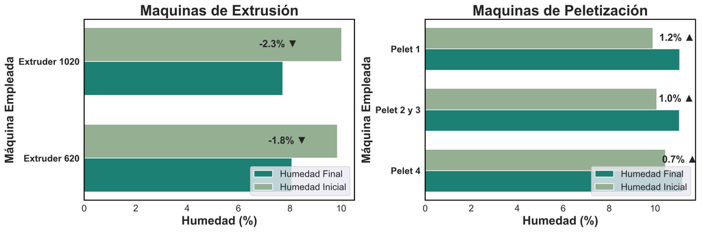

Para los procesos de Extrusión, entre la etapa final e inicial no se observa un aumento en el porcentaje de humedad, por el contrario, **en los procesos de peletización existe un aumento en el porcentaje de agua, que se ve reflejado con una actividad de agua superior a 0.6 %.**

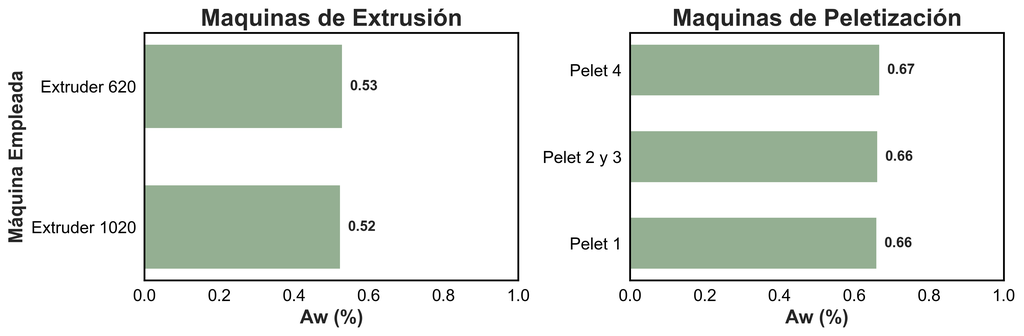

También se puede observar un porcentaje de sackoff superior en los procesos de Extrusión, mientras que en los procesos de peletizado su tendencia es a sackoff cero o por encima de cero.

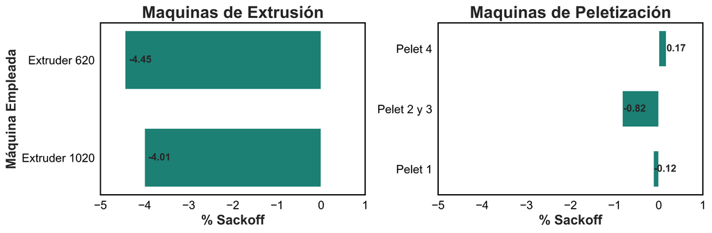

Tener presente el material de inicio de los procesos de extrusión que no salen como producto conforme.

### **Otras medididas en los procesos de peletización**

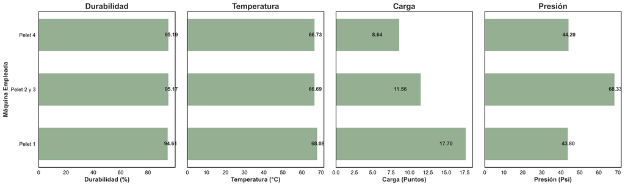

Se ha detectado una notable estabilidad en las mediciones de durabilidad y temperatura, independientemente de la máquina de peletización. En cambio, la carga y la presión —al ser variables intrínsecas a cada equipo— suelen presentar variaciones. Se recomienda no procesar en la peletizadora 1 productos porcícolas que contengan melaza.

#### Fecha de elaboración: 26-12-2025

#### [okuo.bio](https://okuo.bio/)